# Using Artificial Neural Network to Classify Music Genre

## Author: Jayeola Akinola

### Github: github.com/akinolajaye

**Table of Contents**

1. Abstract
2. Learning Objectives
3. Understanding the Dataset
4. Preprocessing Requirements
   - Loading the Dataset
   - Normalising the Data
   - Splitting the Data
   - Convert to Tensors
5. Building the Neural Network
6. Loss
7. Training the Model
8. Evaluating the Model
   - Loss Curve
   - Confusion Matrix
9. Improving Model Performance
   - Learning Rate
   - Epochs
   - Model Architecture
10. Changing to a ResNet Model
    - Changing to spectograms
    - Normalising the spectograms
    - Building the Res Net
    - Training and Results
    - Visualizing High-Dimensional Data with t-SNE
11. Comparison
12. Refrences

## Abstract

Music genre classification, a pivotal task in the realm of audio analysis, serves as the focal point of this tutorial, which embarks on a journey through the application of deep learning for categorizing music into genres. Leveraging the GTZAN dataset, this tutorial is a comprehensive guide to achieve this. From pre-processing data derived from audio, including feature extraction and spectrogram analysis, to the intricate process of building and fine-tuning neural network models utilizing PyTorch. We will focus on model architecture, hyperparameter optimization, and evaluation methodologies. Additionally, the tutorial introduces the use of t-SNE visualization techniques to demystify the distribution of music features across genres, providing a deep dive into the mechanics behind music classification.

## Learning Objectives

By the end of this tutorial, participants will be able to:

1. **Understand the Significance of Music Genre Classification**
   - Explain the importance and applications of music genre classification in various industries, including entertainment, music streaming, and digital libraries.
2. **Familiarize with the GTZAN Dataset**
   - Identify the components and structure of the GTZAN dataset.
   - Understand the role of the GTZAN dataset as a foundational collection in music information retrieval (MIR).
3. **Preprocess Audio and Spectrogram Data**
   - Learn how to load and preprocess audio data (audio features and spectograms) for neural network training.
   - Understand the use of spectrograms for visual representation of sound.
4. **Implement Data Preprocessing Steps**
   - Perform feature extraction and scaling on audio data.
   - Prepare input features and target labels suitable for machine learning models.
5. **Build and Train Neural Network Models**
   - Gain practical skills in constructing and training neural networks using PyTorch.
   - Learn how to define model architecture, including layers and activation functions, for genre classification tasks.
6. **Evaluate Model Performance**
   - Understand the metrics for evaluating the accuracy and effectiveness of classification models.
   - Learn how to use confusion matrices to analyze model performance.
7. **Improve Model Through Hyperparameter Tuning**
   - Experiment with different hyperparameters, including learning rate and epoch number, to enhance model accuracy.
   - Understand the impact of model architecture adjustments on performance.
8. **Explore Advanced Neural Network Architectures**
   - Gain insights into the design and implementation of a Residual Network (ResNet) for music genre classification.
   - Understand the benefits of using ResNet and other deep learning models in handling complex classification tasks.
9. **Visualize High-Dimensional Data**
   - Apply t-SNE (t-Distributed Stochastic Neighbor Embedding) for visualizing the distribution of music features in a two-dimensional space.
   - Interpret t-SNE plots to understand the separability and clustering of music genres based on features.
10. **Apply Practical Machine Learning Workflow**
    - Integrate the entire workflow of a machine learning project, from data preprocessing and model building to evaluation and refinement.
    - Develop a systematic approach to tackling classification problems with neural networks.

First step is to import and install if not installed already the required libraries

```python
import torch.nn as nn
import torch.nn.functional as F
import torch
import pandas as pd
import numpy as np
import seaborn as sns
from sklearn.metrics import confusion_matrix
from sklearn.cluster import KMeans
import matplotlib.pyplot as plt
import seaborn as sns; sns.set()  # For plot styling
```

# Understanding the Dataset

The GTZAN dataset is a foundational collection in the field of music information retrieval (MIR) and audio analysis

The motivation behind the GTZAN dataset is rooted in the quest to deepen our understanding of music through sound analysis. Researchers and experts in music technology, signal processing, and related fields have long been interested in what makes one song distinct from another, how to visualize sound, and the specifics that differentiate one tone from another.

### Content

- **Genres Original**: It comprises a collection of audio files from 10 different musical genres (e.g., blues, classical, country, disco, hip-hop, jazz, metal, pop, reggae, rock), each represented by 100 tracks. Each track is 30 seconds long, offering a snapshot that's both diverse yet concise enough to allow for effective analysis and classification.
- **Images Original**: Understanding that neural networks, particularly Convolutional Neural Networks (CNNs), are adept at handling image data, the dataset includes visual representations of each audio file in the form of Mel Spectrograms. These spectrograms convert sound frequencies into a visual format, enabling researchers to apply image classification techniques to audio analysis. This method leverages the temporal and frequency information encoded in the audio to facilitate its classification or study.
- **CSV Files**: The dataset is complemented by two CSV files detailing extracted audio features from the tracks. One CSV file contains mean and variance values computed over multiple features for each 30-second song. The other file follows a similar structure but for audio segments that have been split into 3-second clips, thereby expanding the dataset and providing more granular data for analysis. This approach acknowledges the principle that more data typically enhances model performance, especially in machine learning applications.

Andrada (n.d.). GTZAN Dataset - Music Genre Classification. [online] www.kaggle.com. Available at: https://www.kaggle.com/datasets/andradaolteanu/gtzan-dataset-music-genre-classification.

## Preprocessing Requirements

### Loading the Dataset

First we load the csv data set for the 30 second clip of each song in each genre If you take a look inside the dataset you will see up to 60 features for each song representing extracted audio features such as chroma_sft_mean which is the average value of processed chroma features also know as chromagrams. They represent the intensity of each of the 12 different pitch classes (C, C#, D, D#, E, F, F#, G, G#, A, A#, B) regardless of octave. (Oluyale, 2023)

```python
df = pd.read_csv("features_30_sec.csv")
df
```

|  | filename | length | chroma_stft_mean | chroma_stft_var | rms_mean | rms_var | spectral_centroid_mean | spectral_centroid_var | spectral_bandwidth_mean | spectral_bandwidth_var | ... | mfcc16_var | mfcc17_mean | mfcc17_var | mfcc18_mean | mfcc18_var | mfcc19_mean | mfcc19_var | mfcc20_mean | mfcc20_var | label |
| --- | --- | --- | --- | --- | --- | --- | --- | --- | --- | --- | --- | --- | --- | --- | --- | --- | --- | --- | --- | --- | --- |
| 0 | blues.00000.wav | 661794 | 0.350088 | 0.088757 | 0.130228 | 0.002827 | 1784.165850 | 129774.064525 | 2002.449060 | 85882.761315 | ... | 52.420910 | -1.690215 | 36.524071 | -0.408979 | 41.597103 | -2.303523 | 55.062923 | 1.221291 | 46.936035 | blues |
| 1 | blues.00001.wav | 661794 | 0.340914 | 0.094980 | 0.095948 | 0.002373 | 1530.176679 | 375850.073649 | 2039.036516 | 213843.755497 | ... | 55.356403 | -0.731125 | 60.314529 | 0.295073 | 48.120598 | -0.283518 | 51.106190 | 0.531217 | 45.786282 | blues |
| 2 | blues.00002.wav | 661794 | 0.363637 | 0.085275 | 0.175570 | 0.002746 | 1552.811865 | 156467.643368 | 1747.702312 | 76254.192257 | ... | 40.598766 | -7.729093 | 47.639427 | -1.816407 | 52.382141 | -3.439720 | 46.639660 | -2.231258 | 30.573025 | blues |
| 3 | blues.00003.wav | 661794 | 0.404785 | 0.093999 | 0.141093 | 0.006346 | 1070.106615 | 184355.942417 | 1596.412872 | 166441.494769 | ... | 44.427753 | -3.319597 | 50.206673 | 0.636965 | 37.319130 | -0.619121 | 37.259739 | -3.407448 | 31.949339 | blues |
| 4 | blues.00004.wav | 661794 | 0.308526 | 0.087841 | 0.091529 | 0.002303 | 1835.004266 | 343399.939274 | 1748.172116 | 88445.209036 | ... | 86.099236 | -5.454034 | 75.269707 | -0.916874 | 53.613918 | -4.404827 | 62.910812 | -11.703234 | 55.195160 | blues |
| ... | ... | ... | ... | ... | ... | ... | ... | ... | ... | ... | ... | ... | ... | ... | ... | ... | ... | ... | ... | ... | ... |
| 995 | rock.00095.wav | 661794 | 0.352063 | 0.080487 | 0.079486 | 0.000345 | 2008.149458 | 282174.689224 | 2106.541053 | 88609.749506 | ... | 45.050526 | -13.289984 | 41.754955 | 2.484145 | 36.778877 | -6.713265 | 54.866825 | -1.193787 | 49.950665 | rock |
| 996 | rock.00096.wav | 661794 | 0.398687 | 0.075086 | 0.076458 | 0.000588 | 2006.843354 | 182114.709510 | 2068.942009 | 82426.016726 | ... | 33.851742 | -10.848309 | 39.395096 | 1.881229 | 32.010040 | -7.461491 | 39.196327 | -2.795338 | 31.773624 | rock |
| 997 | rock.00097.wav | 661794 | 0.432142 | 0.075268 | 0.081651 | 0.000322 | 2077.526598 | 231657.968040 | 1927.293153 | 74717.124394 | ... | 33.597008 | -12.845291 | 36.367264 | 3.440978 | 36.001110 | -12.588070 | 42.502201 | -2.106337 | 29.865515 | rock |
| 998 | rock.00098.wav | 661794 | 0.362485 | 0.091506 | 0.083860 | 0.001211 | 1398.699344 | 240318.731073 | 1818.450280 | 109090.207161 | ... | 46.324894 | -4.416050 | 43.583942 | 1.556207 | 34.331261 | -5.041897 | 47.227180 | -3.590644 | 41.299088 | rock |
| 999 | rock.00099.wav | 661794 | 0.358401 | 0.085884 | 0.054454 | 0.000336 | 1609.795082 | 422203.216152 | 1797.213044 | 120115.632927 | ... | 59.167755 | -7.069775 | 73.760391 | 0.028346 | 76.504326 | -2.025783 | 72.189316 | 1.155239 | 49.662510 | rock |

1000 rows × 60 columns

In the process of creating your neural network for music genre classification, a key step is to prep your dataset for training. This means splitting your data into input features, which the model learns from, and target labels, which it aims to predict.

Input Features Preparation Remove the non-feature columns "label" and "filename" from your DataFrame df, leaving you with just the musical attributes necessary for learning:  
This line creates an numpy array of input features by excluding the genre labels and file names

```python
X_input_features = df.drop(labels=["label","filename"],axis=1).values
(X_input_features)
```

```
array([[ 6.61794000e+05,  3.50088120e-01,  8.87565687e-02, ...,
         5.50629234e+01,  1.22129071e+00,  4.69360352e+01],
       [ 6.61794000e+05,  3.40913594e-01,  9.49802548e-02, ...,
         5.11061897e+01,  5.31216502e-01,  4.57862816e+01],
       [ 6.61794000e+05,  3.63637179e-01,  8.52751955e-02, ...,
         4.66396599e+01, -2.23125839e+00,  3.05730247e+01],
       ...,
       [ 6.61794000e+05,  4.32142019e-01,  7.52684996e-02, ...,
         4.25022011e+01, -2.10633659e+00,  2.98655148e+01],
       [ 6.61794000e+05,  3.62484574e-01,  9.15055275e-02, ...,
         4.72271805e+01, -3.59064364e+00,  4.12990875e+01],
       [ 6.61794000e+05,  3.58401328e-01,  8.58840942e-02, ...,
         7.21893158e+01,  1.15523911e+00,  4.96625099e+01]])
```

Target Labels Extraction Extract the music genre labels from the "label" column, as these are your target outcomes for prediction:

```python
y_predictors= df["label"].values
```

### Normalising the Data

It's crucial that all inputs and outputs are in a format the model can understand. For the output labels, this often means encoding categorical data (like genre names) into numerical format. This conversion is essential because neural networks work with numerical data, not text labels.

```python
from sklearn.preprocessing import LabelEncoder
label_encoder = LabelEncoder()
y_encoded_predictors = label_encoder.fit_transform(y_predictors)
```

For optimal performance of your neural network, it's essential to scale your input features. This process adjusts the features so they have a mean of 0 and a standard deviation of 1, enhancing model training by ensuring no input feature dominates due to its scale. To achieve this, you utilize the `StandardScaler` from the `scikit-learn` library, a widely used Python library for machine learning.

### Reference

["sklearn.preprocessing.StandardScaler"](https://scikit-learn.org/stable/modules/generated/sklearn.preprocessing.StandardScaler.html)  
["Normalization"](https://developers.google.com/machine-learning/data-prep/transform/normalization)

```python
from sklearn.preprocessing import StandardScaler
scaler = StandardScaler() # reference sci kit
X_input_feat_scaled = scaler.fit_transform(X_input_features)
X_input_feat_scaled
```

```
array([[-0.13282213, -0.35013678,  0.31258717, ..., -0.30059734,
         0.60406407, -0.51298758],
       [-0.13282213, -0.46248155,  1.11757233, ..., -0.40708699,
         0.42412706, -0.53842129],
       [-0.13282213, -0.18422456, -0.13770124, ..., -0.52729705,
        -0.29618888, -0.8749539 ],
       ...,
       [-0.13282213,  0.65463736, -1.43198917, ..., -0.63865065,
        -0.26361549, -0.89060474],
       [-0.13282213, -0.19833855,  0.66814351, ..., -0.5114848 ,
        -0.65064889, -0.63768256],
       [-0.13282213, -0.2483391 , -0.05894495, ...,  0.16033426,
         0.5868411 , -0.4526752 ]])
```

### Splitting the Data

Before training your neural network on the music genre classification task, it's crucial to split your dataset into training and testing subsets. This step is fundamental in machine learning to evaluate the model's performance on unseen data, ensuring that it generalizes well and isn't just memorizing the training data. The `train_test_split` function from `scikit-learn`'s `model_selection` module is a convenient tool for this purpose.

#### Why Split the Data?

Splitting the data into training and testing sets allows you to:

- **Train the model** on a large portion of the dataset (training set).
- **Test the model** on a separate, unseen portion of the dataset (testing set) to evaluate its performance.

This method helps detect overfitting, where the model performs well on the training data but poorly on new, unseen data.

Here's what each parameter and variable means:

- **`X_input_feat_scaled`**: The scaled input features you prepared earlier, ready for the model.
- **`y_encoded_predictors`**: The numerically encoded genre labels.
- **`test_size=0.2`**: This specifies that 20% of the data will be used as the testing set, leaving 80% for training. The choice of size depends on the dataset's size and the training needs.
- **`shuffle=True`**: Before splitting, shuffle the data to ensure that the distribution of genres is random and representative across both training and testing sets.

The function returns four arrays:

- **`X_train`** and **`y_train`**: The features and labels for the training set.
- **`X_test`** and **`y_test`**: The features and labels for the testing set.

### Reference

["sklearn.model_selection.train_test_split"](https://scikit-learn.org/stable/modules/generated/sklearn.model_selection.train_test_split.html)

```python
from sklearn.model_selection import train_test_split

X_train, X_test, y_train, y_test = train_test_split(X_input_feat_scaled, y_encoded_predictors, test_size=0.2, shuffle=True)
```

## Convert to Tensors

After splitting your dataset into training and testing sets for your music genre classification project, the next step involves converting these sets into tensors for use with PyTorch. PyTorch, being a deep learning framework, works with data in the form of tensors, which are a generalization of vectors and matrices to potentially higher dimensions.

#### Why Convert to Tensors?

Tensors are the primary data structure used by PyTorch for all operations. Converting your dataset into tensors allows you to leverage PyTorch's powerful GPU acceleration for faster computation, as well as its automatic differentiation capabilities, which are essential for training neural networks.

By converting your dataset into PyTorch tensors, you've effectively prepared your data for training and evaluation within the PyTorch framework. This preparation is essential for utilizing the full capabilities of PyTorch, including efficient computations on GPU and seamless integration with PyTorch's model training and evaluation workflows. With your data now in the correct format, you're ready to define and train your neural network model for music genre classification.

### Reference

The implementation of using tensors in this way was adapted from ["PyTorch Loss Functions: The Ultimate Guide"](https://neptune.ai/blog/pytorch-loss-functions). This resource provides valuable insights and practical advice for both beginners and experienced practitioners in the field. (Opidi and Jha, 2020)

```python
X_train_tensor = torch.FloatTensor(X_train)
y_train_tensor = torch.LongTensor(y_train)

X_test_tensor = torch.FloatTensor(X_test)
y_test_tensor = torch.LongTensor(y_test)


X_train_tensor
```

```
tensor([[-0.1328,  1.1678, -0.2024,  ...,  0.1474,  0.2039, -0.0794],
        [-0.1328, -1.5267,  0.3391,  ...,  1.9271, -0.9906,  1.3475],
        [-0.1328, -1.4469,  0.7079,  ...,  2.9794, -1.7897,  1.5034],
        ...,
        [-0.2955,  0.2130,  0.4609,  ..., -0.7454,  0.2780, -0.5823],
        [-0.1328, -1.1338, -0.2635,  ..., -0.9539,  0.6063, -0.6217],
        [ 7.7262,  0.2407,  1.1375,  ..., -0.4586, -0.5670, -0.1764]])
```

The shape shows that the train data has 80% of thr values

```python
X_train_tensor.shape
```

```
torch.Size([800, 58])
```

With your dataset converted into PyTorch tensors, the next crucial step in preparing for neural network training involves organizing these tensors into datasets and data loaders.

### Creating TensorDatasets

PyTorch's `TensorDataset` is a wrapper around tensors that provides a convenient way to iterate over datasets. By creating a `TensorDataset`, you combine the input features and target labels into a single dataset object, simplifying the process of working with the data.

This step encapsulates your training and testing data into `TensorDataset` objects, making it easier to access and manipulate the data during training and evaluation.

### Utilizing DataLoaders

To further facilitate the training process, PyTorch's `DataLoader` is used to split the dataset into manageable batches. This is crucial for training neural networks, as it allows for batch processing, which is more efficient than processing the entire dataset at once. It also enables shuffle capabilities which help in reducing overfitting by ensuring that the model does not learn the order of the training data.

In these lines:

- `batch_size=64` determines the number of samples per batch. This value is chosen based on memory constraints and the need for stochastic gradient descent optimization; it can be adjusted for optimal performance.
- `shuffle=False` is set here, because we already shuffled the data previously

By creating `TensorDataset` objects and utilizing `DataLoader`, you've streamlined the process of feeding data into your neural network for both training and evaluation. This setup not only optimizes memory usage and computation but also introduces the flexibility to shuffle data and batch processing, which are essential practices for effective neural network training. With your data now ready in a structured format, you're set to move forward with defining and training your model for music genre classification.

### Reference

["Datasets & DataLoaders"](https://pytorch.org/tutorials/beginner/basics/data_tutorial.html)

```python
from torch.utils.data import DataLoader, TensorDataset

train_dataset = TensorDataset(X_train_tensor, y_train_tensor)
test_dataset = TensorDataset(X_test_tensor, y_test_tensor)

train_loader = DataLoader(dataset=train_dataset, batch_size=64, shuffle=False)
test_loader = DataLoader(dataset=test_dataset, batch_size=64, shuffle=False)
```

```python
x_input_size = X_train_tensor.shape[1]
```

# Building the Neural Network

After preparing your dataset and loading it into PyTorch DataLoader objects for efficient batch processing during training, the next critical step in building your music genre classification neural network is to define the model architecture itself. In this step, you'll construct a Multilayer Perceptron (MLP), a type of feedforward neural network, using PyTorch's `nn.Sequential` container along with an `OrderedDict` to neatly organize the layers and operations.

An MLP is a class of feedforward artificial neural network that consists of at least three layers of nodes: an input layer, one or more hidden layers, and an output layer. Except for the input nodes, each node is a neuron with a nonlinear activation function.

### Defining the MLP Model Architecture

#### Understanding `nn.Sequential` and `OrderedDict`

- **`nn.Sequential`**: This PyTorch module allows you to create a linear stack of layers where the output of one layer is sequentially fed as the input to the next. It's a convenient way to build networks when the data flows straight through without any branches or merges.
- **`OrderedDict`**: By using an `OrderedDict` from the Python `collections` module, you can specify the layers in your network in an ordered manner. This also allows you to name each layer, making the model more readable and easier to debug.

### Model Architecture

- **Input Layer (`"dense1"`)**: This is the first layer of the network which receives the input data. The number of neurons (`out_features=100`) in this layer is set to start the process of learning features from the data. In our model, it's connected to the input features of the dataset (`in_features=x_input_size`).
- **ReLU Activation (`'activation_layer1'`)**: Following the input layer, we have a Rectified Linear Unit (ReLU) activation function. ReLU introduces non-linearity to the model, allowing it to learn more complex patterns. It's defined as `f(x) = max(0, x)`, effectively turning off neurons that output negative values and addressing the vanishing gradient problem in deep networks.
- **Hidden Layers (`"dense2"` and `"dense3"`)**: These layers allow the network to learn more complex representations by combining the features learned in the preceding layers. They each have a decreasing number of neurons, which helps in condensing the information down to the most essential features before reaching the output layer.
- **More ReLU Activations (`'activation_layer2'` and `'activation_layer3'`)**: Each hidden layer is followed by another ReLU activation function, which continues to add non-linearity to the processing of data as it moves through the network.
- **Output Layer (`"output"`)**: The output layer translates the features learned by the network into final predictions. For a classification task with 10 classes (such as 10 different music genres), we have 10 neurons, each representing a class. The network's prediction is the neuron with the highest value after applying the activation function.
- **Softmax Activation (`"output activation"`)**: The Softmax function is applied in the output layer for multi-class classification problems. It converts the output logits (raw prediction scores) into probabilities by normalizing them into a probability distribution consisting of probabilities proportional to the exponentials of the input numbers. The `dim=1` argument specifies that the Softmax function should be applied across the columns, not the rows.

### Reference

The implementation of this architecture was adapted from ["Building Multilayer Perceptron Models in PyTorch"](https://machinelearningmastery.com/building-multilayer-perceptron-models-in-pytorch/) on Machine Learning Mastery. This resource provides valuable insights and practical advice for both beginners and experienced practitioners in the field.

```python
from collections import OrderedDict
model = nn.Sequential(OrderedDict([("dense1",nn.Linear(in_features=x_input_size,out_features=100) ),
                                    ('activation_layer1', nn.ReLU()),
                                    ("dense2",nn.Linear(in_features=100,out_features=50) ),
                                    ('activation_layer2', nn.ReLU()),
                                    ("dense3",nn.Linear(in_features=50,out_features=25) ),
                                    ('activation_layer3', nn.ReLU()),
                                    ("output",nn.Linear(25,10)),
                                    ("output activation",nn.Softmax(dim=1))
]))
```

# Loss

In building your neural network for music genre classification using PyTorch, after defining the model architecture, the next crucial steps are selecting a loss function and an optimizer. These components are essential for training your model effectively.

### Selecting the Loss Function

For this task, we will use the **Cross-Entropy Loss**, which is ideal for multi-class classification problems. This loss function measures the performance of a classification model whose output is a probability value between 0 and 1. Cross-Entropy Loss increases as the predicted probability diverges from the actual label, making it perfect for scenarios where you're classifying data into multiple categories.

### Choosing the Optimizer

The **Adam optimizer** is chosen for adjusting the weights of your network. Adam is known for its effectiveness in handling sparse gradients and adapting the learning rate for each parameter, making it a suitable choice for a wide range of problems. You'll set an initial learning rate of `0.001`, which is a good starting point for many deep learning tasks.

By defining the `loss_function` as `CrossEntropyLoss` and selecting `Adam` as your `optimizer`, you've completed an essential configuration for your model's training process. This setup directs how your model learns from the training data—minimizing the loss function through the optimizer's adjustments to the model parameters—paving the way towards achieving high accuracy in music genre classification.

Next, you'll proceed to the training loop, where these components will be put into action as your model learns from the data.

### Reference

["Train your data analysis model with PyTorch"](https://learn.microsoft.com/en-us/windows/ai/windows-ml/tutorials/pytorch-analysis-train-model)

```python
from torch.optim import Adam
# Loss and optimizer
loss_function = nn.CrossEntropyLoss()
optimizer = Adam(model.parameters(), lr=0.001)
```

# Training the Model

When training a neural network for tasks such as music genre classification, it's essential to implement a training loop that iteratively updates the model's weights based on the training data.

### Implementing the Training Function

This function is designed to train the neural network model by iterating over all batches of training data, calculating the loss for each batch, and updating the model parameters accordingly.

#### Importing tqdm

First, you import `tqdm`. This library is used to display progress bars that give you feedback about the training process, including how much work is done and how much work remains.

#### Defining the Train Function

- **`model.train()`**: This tells PyTorch that you're in training mode, which activates features like dropout and batch normalization, which are relevant during training but not during testing.

#### Initializing Running Loss

- **Running Loss**: Tracks the sum of the losses over all batches within an epoch, allowing you to calculate the average loss later.

#### Looping Over the DataLoader

- Iterates over the training data loader, which provides batches of `inputs` (features) and `labels` (targets). The `tqdm` wrapper adds a progress bar for visual feedback.
- **Forward Pass**: The model computes predictions (`y_pred`) for the current batch of inputs, and then the loss is calculated based on these predictions and the true labels.

#### Backward Pass and Optimization

- **Zero Gradients**: Clears old gradients from the last step (otherwise they will accumulate).
- **Backward Pass**: Calculates the gradient of the loss with respect to each parameter.
- **Optimizer Step**: Adjusts the parameters based on the calculated gradients.

#### Accumulate Loss

- Accumulates the loss of each batch to calculate the total loss for the epoch.

#### Calculating Average Loss

- Returns the average loss per batch over the entire epoch, providing a measure of how well the model is learning.

The `train` function encapsulates the core steps of training a neural network with PyTorch: preparing the model, looping over the data, conducting forward and backward passes, and updating model parameters. By carefully implementing and understanding each part of this process, you are well on your way to successfully training your model for the task of music genre classification.

### Reference

["Train your data analysis model with PyTorch"](https://learn.microsoft.com/en-us/windows/ai/windows-ml/tutorials/pytorch-analysis-train-model)

```python
import tqdm
def train():
    model.train()
    running_loss = 0.0
    for inputs, labels in (train_loader):

        y_pred = model(inputs)
        loss = loss_function(y_pred, labels)
        optimizer.zero_grad()
        loss.backward()
        optimizer.step()

        running_loss += loss.item()
    return (running_loss / len(train_loader))
```

```python
loss_values=[]
for epoch in range(100):
  loss =train()
  if epoch % 10 ==0:
    print(f"Epoch {epoch:03d}, Loss {loss:.4f}")
  loss_values.append(loss)
#   scheduler.step()
```

```
Epoch 000, Loss 2.2996
Epoch 010, Loss 1.9051
Epoch 020, Loss 1.7916
Epoch 030, Loss 1.6721
Epoch 040, Loss 1.5999
Epoch 050, Loss 1.5670
Epoch 060, Loss 1.5519
Epoch 070, Loss 1.5462
Epoch 080, Loss 1.5434
Epoch 090, Loss 1.5405
```

# Evaluating the Model

## Results

After training, evaluating the model's performance on the test set is crucial to understand how well it generalizes to unseen data. The evaluation procedure involves:

1. **Set Model to Evaluation Mode**: This step is critical as it informs the model that it is in evaluation phase, disabling dropout and batch normalization layers.
2. **Disable Gradient Computation**: Wrapping the evaluation code in `with torch.no_grad():` disables gradient calculations, saving memory and computations.
3. **Initialize Counters**: `correct` and `total` variables track the number of correct predictions and the total predictions, respectively.
4. **Iterate Over Test Data**: Process each batch from the test dataset.
5. **Compute Outputs**: The model predicts the genre for each input batch.
6. **Select the Class with the Highest Probability**: `torch.max(outputs.data, 1)` determines the predicted class for each example.
7. **Update Counters**: Compare predictions with true labels to calculate the number of correct predictions.
8. **Calculate Accuracy**: Compute the percentage of correct predictions over the total number of examples in the test set.

```python
model.eval()  # Set the model to evaluation mode
with torch.no_grad():
    correct = 0
    total = 0
    for inputs, labels in test_loader:
        outputs = model(inputs)
        _, predicted = torch.max(outputs.data, 1)
        total += labels.size(0)
        correct += (predicted == labels).sum().item()

print(f'Accuracy of the model on the test set: {100 * correct / total}%')
```

```
Accuracy of the model on the test set: 74.0%
```

```python
predicted
```

```
tensor([1, 9, 7, 8, 3, 1, 3, 1])
```

```python
labels
```

```
tensor([1, 9, 8, 8, 3, 1, 8, 1])
```

# Plotting the Loss Curve

1. **Import Matplotlib**: Ensure you have `matplotlib` imported to use its plotting capabilities:
2. **Create a Figure**: Initialize a new figure for your plots. This acts as a container for all your plots. The `figsize` parameter allows you to specify the width and height of your figure in inches.
3. **Add a Subplot for the Loss Curve**: Use `plt.subplot()` to add a subplot to your figure. The parameters `(1, 2, 1)` indicate that your figure is organized into a grid with 1 row and 2 columns, and you're creating your first plot in this grid. This setup allows for additional plots, such as an accuracy curve, to be added alongside the loss curve.
4. **Plot the Loss Values**: Use `plt.plot()` to draw the loss curve, passing `loss_values` as the data to plot. The `label` parameter is used to create a legend for the plot.
5. **Customize the Plot**: Add a title, and labels for the x-axis and y-axis to make the plot informative. The title helps identify the plot's purpose, and the axis labels clarify what the plot dimensions represent.
6. **Add a Legend**: To make it clear what the plotted line represents, add a legend to your plot.
7. **Display the Plot**: Finally, to display the plot, you can simply call `plt.show()` at the end of your plotting code. This step is optional in many environments where plots are automatically displayed after running the plotting commands.

Plotting the loss curve is a crucial part of the model evaluation process, providing insights into how well your model is learning from the training data. A decreasing loss curve indicates that the model is learning effectively, while any anomalies or patterns in the curve can help diagnose issues with the training process, such as overfitting or underfitting.

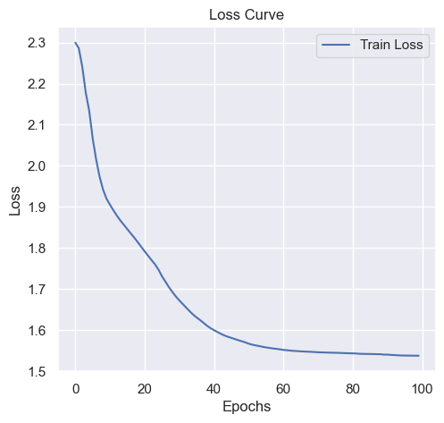

```python
import matplotlib.pyplot as plt
# Plotting
plt.figure(figsize=(12, 5))
plt.subplot(1, 2, 1)
plt.plot(loss_values, label='Train Loss')
plt.title('Loss Curve')
plt.xlabel('Epochs')
plt.ylabel('Loss')
plt.legend()
```

Here we can see that our network is learning effectively from the data

# Generating the Confusion Matrix

To visualize the performance of your music genre classification model beyond just accuracy, a confusion matrix is an excellent tool. It provides detailed insight into how well the model distinguishes between different genres, highlighting not just the successes but also where the model tends to make errors.

The confusion matrix is computed using `confusion_matrix` from `sklearn.metrics`, comparing the true labels with the predicted ones. Each cell [i, j] in the matrix indicates the number of samples with true label i and predicted label j.

### Plotting the Confusion Matrix

To visualize the confusion matrix:

- Use `sns.heatmap` from the seaborn library to create a heatmap representation of the confusion matrix.
- `cm` is passed as the data for the heatmap.
- `annot=True` displays the number of instances in each cell.
- `fmt="d"` formats the annotation numbers as integers.
- `cmap='Blues'` sets the color scheme.
- `xticklabels` and `yticklabels` are set to `genre_names`, which correspond to the class names extracted from `label_encoder.classes_`, ensuring the genres are correctly labeled on both axes.

### Interpretation

In the confusion matrix:

- The diagonal cells (from top left to bottom right) show the number of correct predictions for each genre.
- Off-diagonal cells indicate misclassifications, where the model has predicted a genre different from the true label.
- Ideally, you want high numbers on the diagonal (indicating many correct classifications) and low numbers off-diagonal (indicating few misclassifications).

### Reference

Adapted from ["Confusion Matrix Visualization"](https://medium.com/@dtuk81/confusion-matrix-visualization-fc31e3f30fea)

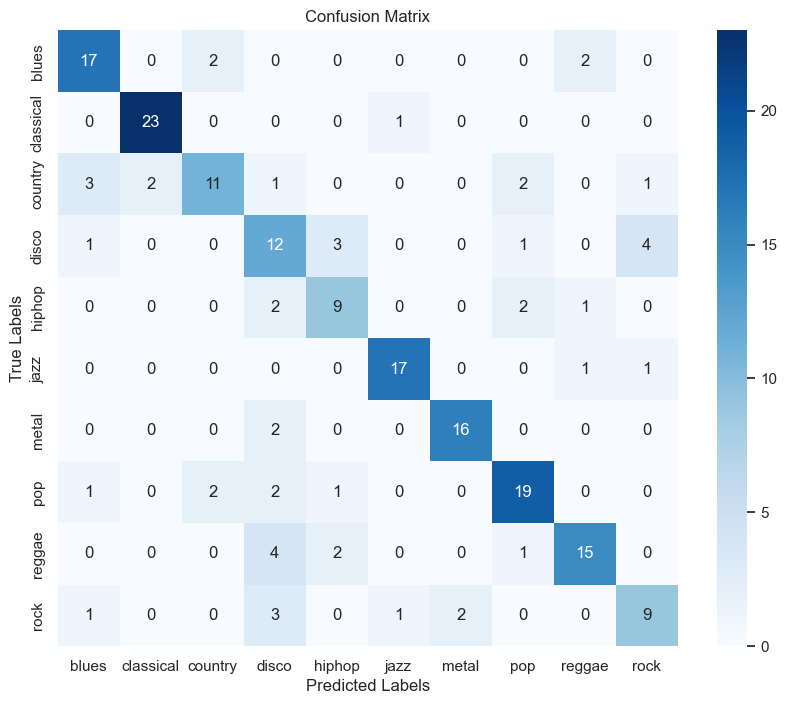

```python
genre_names = label_encoder.classes_

all_preds = []
all_true_labels = []

# Evaluation loop to collect predictions and actual labels
model.eval()
with torch.no_grad():
    for inputs, labels in test_loader:
        outputs = model(inputs)
        _, predicted = torch.max(outputs, 1)
        all_preds.extend(predicted.cpu().numpy())
        all_true_labels.extend(labels.cpu().numpy())

# Compute the confusion matrix
cm = confusion_matrix(all_true_labels, all_preds)

# Plotting the confusion matrix
plt.figure(figsize=(10, 8))
sns.heatmap(cm, annot=True, fmt="d", cmap='Blues', xticklabels=genre_names, yticklabels=genre_names)
plt.xlabel('Predicted Labels')
plt.ylabel('True Labels')
plt.title('Confusion Matrix')
plt.show()
```

```python
import pandas as pd
from sklearn.metrics import classification_report


# Calculate precision, recall, f1-score, and support
report_dict = classification_report(all_true_labels, all_preds, output_dict=True)

# Create a DataFrame from the report dictionary
report_df = pd.DataFrame(report_dict).transpose()

# Rename index to use genre names
report_df.index = list(genre_names) + ['accuracy', 'macro avg', 'weighted avg']

# Display the DataFrame as a table
print(report_df)
```

```
              precision    recall  f1-score  support
blues          0.739130  0.809524  0.772727    21.00
classical      0.920000  0.958333  0.938776    24.00
country        0.733333  0.550000  0.628571    20.00
disco          0.461538  0.571429  0.510638    21.00
hiphop         0.600000  0.642857  0.620690    14.00
jazz           0.894737  0.894737  0.894737    19.00
metal          0.888889  0.888889  0.888889    18.00
pop            0.760000  0.760000  0.760000    25.00
reggae         0.789474  0.681818  0.731707    22.00
rock           0.600000  0.562500  0.580645    16.00
accuracy       0.740000  0.740000  0.740000     0.74
macro avg      0.738710  0.732009  0.732738   200.00
weighted avg   0.746646  0.740000  0.740651   200.00
```

### Understanding the Metrics

- **Precision**: Precision measures the accuracy of the positive predictions. It is the ratio of correctly predicted positive observations to the total predicted positives. High precision relates to a low false positive rate.
- **Recall**: Recall (also known as sensitivity) is the ratio of correctly predicted positive observations to all actual positives. It measures the model's ability to find all the relevant cases within a dataset.
- **F1-Score**: The F1 Score is the harmonic mean of precision and recall. An F1 score reaches its best value at 1 (perfect precision and recall) and worst at 0.
- **Support**: The support is the number of actual occurrences of the class in the dataset. It is the number of true instances for each label.

### Reading the Table

# Can We Get Better Results

We dive into hyperparameter tuning to enhance the performance of our music genre classification model. Hyperparameters, the settings adjusted before training, can significantly impact a model's learning ability and accuracy. By tweaking aspects like learning rate, batch size, and neural network architecture, we aim to improve our model's efficiency and predictive power. Through systematic experimentation with these hyperparameters, we'll uncover insights on optimizing our model for better result

### Adjusting the Learning Rate in the Optimizer

The learning rate has been updated from an initial setting of 0.001 to a lower value of 1e-4 (0.0001). This modification is reflected in the optimizer's configuration as follows:

### Why This Change?

- **Encouraging Finer Adjustments**: Lowering the learning rate to 1e-4 aims to enable the model to make finer adjustments to the weights during training. This is particularly beneficial for fine-tuning the model as it approaches the minimum of the loss function, potentially leading to a more accurate and generalized solution.
- **Reducing Training Oscillations**: A smaller learning rate decreases the risk of significant oscillations in the loss landscape. This can be crucial in preventing the model from overshooting the optimal point during training.
- **Enhanced Model Stability**: By adopting a more conservative approach to the learning rate, we anticipate enhanced stability in the training process. This stability can be particularly advantageous in the later stages of training, where preserving and incrementally improving upon the learned patterns becomes essential.

Note: code to re initialise parmeters such as making a new model and re running the trainig have been abstracted as to just focus on the code where changes have been made

```python
loss_function = nn.CrossEntropyLoss()
optimizer = Adam(model.parameters(), lr=1e-4)
```

```
Epoch 000, Loss 2.3022
Epoch 010, Loss 2.2821
Epoch 020, Loss 2.1919
Epoch 030, Loss 2.1133
Epoch 040, Loss 2.0634
Epoch 050, Loss 2.0083
Epoch 060, Loss 1.9692
Epoch 070, Loss 1.9395
Epoch 080, Loss 1.9112
Epoch 090, Loss 1.8844
Accuracy of the model on the test set: 60.5%
```

# Results

- **Slower Convergence**: The reduced learning rate may have slowed down the training process significantly, preventing the model from adequately converging to the best solution within the given number of epochs. Essentially, the model might not have "learned" enough to maintain or improve its accuracy. This is evident from the slpoe of the loss curve
- **Insufficient Training**: With a smaller learning rate, the model requires more iterations to traverse the loss landscape and possibly arrive at a lower loss minimum. If the training epochs were not increased to compensate for the slower learning rate, the model might not have reached its full learning potential.
- **Hyperparameter Balance**: The decrease in performance underscores the delicate balance required in hyperparameter tuning. It suggests that the previous learning rate, although higher, was closer to the model's optimal learning rate for the given setup and data.

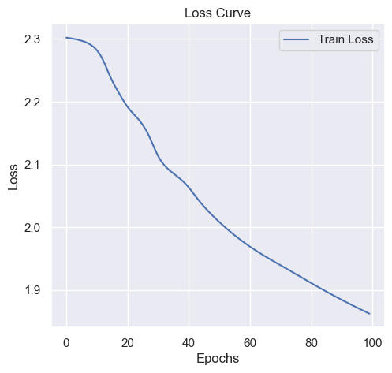

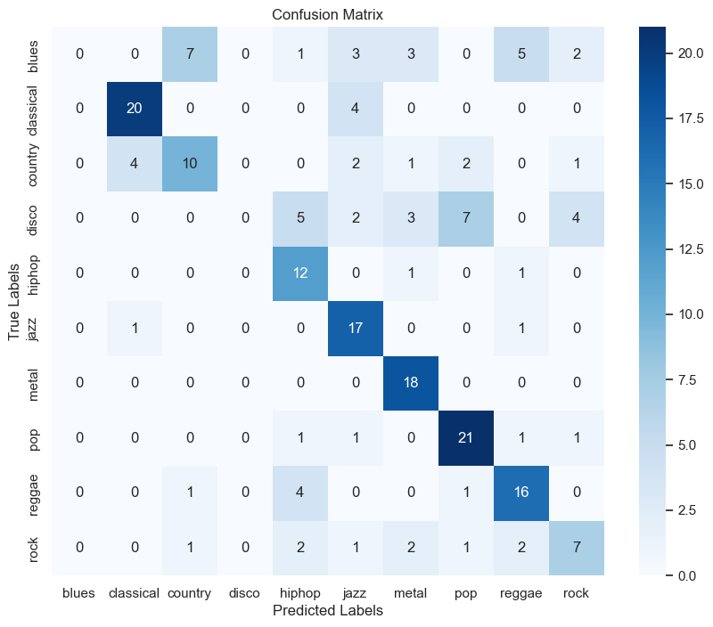

| Genre | Precision | Recall | F1-Score | Support |
| --- | --- | --- | --- | --- |
| blues | 0.000 | 0.000 | 0.000 | 21.0 |
| classical | 0.800 | 0.833 | 0.816 | 24.0 |
| country | 0.526 | 0.500 | 0.513 | 20.0 |
| disco | 0.000 | 0.000 | 0.000 | 21.0 |
| hiphop | 0.480 | 0.857 | 0.615 | 14.0 |
| jazz | 0.567 | 0.895 | 0.694 | 19.0 |
| metal | 0.643 | 1.000 | 0.783 | 18.0 |
| pop | 0.656 | 0.840 | 0.737 | 25.0 |
| reggae | 0.615 | 0.727 | 0.667 | 22.0 |
| rock | 0.467 | 0.438 | 0.452 | 16.0 |
| **Accuracy** |  |  | **0.605** | 0.605 |
| **Macro Avg** | 0.475 | 0.609 | 0.528 | 200.0 |
| **Weighted Avg** | 0.481 | 0.605 | 0.530 | 200.0 |

### Adjusting the number of epochs

In light of reverting the learning rate to 0.001 and aiming to capitalize on the model's learning dynamics, we are also extending the training duration from 100 to 200 epochs. This dual adjustment is designed to provide the model with more extensive learning opportunities, potentially enhancing its ability to capture and generalize from the musical features for genre classification.

### Purpose and Expected Outcomes

- **Maximizing Learning Potential**: Doubling the number of epochs gives the model additional iterations to learn from the dataset, crucial for deepening its understanding and refining its predictions, especially after adjusting the learning rate back to 0.001.
- **Balancing Learning Rate and Epochs**: The chosen learning rate of 0.001, known for its effective balance between speed and stability in convergence, paired with an extended training period, aims to optimize the model's learning curve without the risk of quick overfitting.
- **Monitoring Model Performance**: With the increased number of epochs, it's essential to closely monitor the model's performance over time. This includes watching for diminishing returns in accuracy improvements and signs of overfitting, ensuring the model remains generalized to unseen data.

This strategy acknowledges that the initial learning rate of 0.001 provided a solid foundation for model training, reflecting a nuanced understanding of the model's behavior under different configurations. By reverting to this learning rate while extending the epochs, the approach is fine-tuned to leverage the strengths of the model's initial setup, aiming for improved or restored accuracy levels.

```python
loss_values=[]
for epoch in range(200):
  loss =train(model)
  loss_values.append(loss)
```

```
Accuracy of the model on the test set: 74.5%
```

# Results

The slight increase in accuracy from 74% to 74.5%, following the extension of the training period to 200 epochs and the adjustment of the learning rate back to 0.001, provides valuable insights into the model's learning dynamics and capacity for improvement under the current setup. While the increment is modest, it confirms several key aspects of the training process and model optimization.

### Interpretation of Results

- **Stabilization of Learning**: The minimal increase in accuracy suggests that the model has potentially reached a plateau in its learning capability under the current architecture and training configuration. This indicates a stabilization where further increases in epochs or minor adjustments in the learning rate may not lead to significant performance gains.
- **Optimization of Hyperparameters**: The decision to revert the learning rate to 0.001 and increase the training epochs appears to have optimized the training process to a point where accuracy improvements are marginal. This could mean that the chosen hyperparameters are close to optimal for the current model architecture and dataset.
- **Considerations for Further Improvements**: The relatively stable accuracy suggests it might be time to explore other avenues for enhancement. This includes experimenting with more substantial changes to the model architecture, data augmentation techniques, or incorporating additional features that could provide new learning pathways for the model.

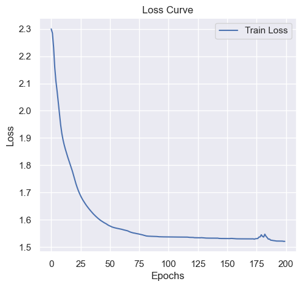

### Next Steps in Model Optimization

Given the current plateau in accuracy improvements, consider the following strategies for further model refinement:

- **Model Architecture Adjustments**: Explore modifications in the neural network architecture, such as adding or reducing layers, changing layer sizes, or experimenting with different activation functions, to discover new configurations that might capture the complexity of the dataset more effectively.

# Update to Model Architecture

The neural network's architecture has been simplified and slightly expanded in its initial layer:

### Changes Explained

- **Increased Units in the First Layer**: The number of units in the first dense layer has been increased from 100 to 150. This change aims to allow the model to capture a broader and potentially more complex set of features from the input data right from the start, which could lead to better classification performance.
- **Streamlined Architecture**: By removing one of the intermediate layers (previously moving from 100 to 50 units), the model now transitions directly from 150 units in the first layer to 25 units in the second layer before reaching the output. This simplification is designed to reduce the complexity of the model, potentially improving its generalizability and efficiency without sacrificing its ability to learn meaningful patterns.
- **Maintained Output Configuration**: The output layer configuration remains unchanged, with a transition to 10 units followed by a Softmax activation. This ensures that the model's final output is a probability distribution over the 10 target classes (music genres), suitable for classification tasks.

```python
x_input_size = X_train_tensor.shape[1]

model = nn.Sequential(OrderedDict([("dense1",nn.Linear(in_features=x_input_size,out_features=150) ),
                                    ('activation_layer1', nn.ReLU()),
                                    ("dense3",nn.Linear(in_features=150,out_features=25) ),
                                    ('activation_layer3', nn.ReLU()),
                                    ("output",nn.Linear(25,10)),
                                    ("output activation",nn.Softmax(dim=1))
]))
loss_function = nn.CrossEntropyLoss()
optimizer = Adam(model.parameters(), lr=0.001)


import tqdm
def train(model):
    model.train()
    running_loss = 0.0
    for inputs, labels in (train_loader):

        y_pred = model(inputs)
        loss = loss_function(y_pred, labels)
        optimizer.zero_grad()
        loss.backward()
        optimizer.step()

        running_loss += loss.item()
    return (running_loss / len(train_loader))


loss_values=[]
for epoch in range(200):
  loss =train(model)
  loss_values.append(loss)
#   scheduler.step()


model.eval()  # Set the model to evaluation mode
with torch.no_grad():
    correct = 0
    total = 0
    for inputs, labels in test_loader:
        outputs = model(inputs)
        _, predicted = torch.max(outputs.data, 1)
        total += labels.size(0)
        correct += (predicted == labels).sum().item()

print(f'Accuracy of the model on the test set: {100 * correct / total}%')
```

```
Accuracy of the model on the test set: 76.5%
```

# Results

### Key Takeaways

- **Enhanced Feature Representation**: The increase in units within the initial layer likely provided the model with a more robust capability to capture and represent the nuances in the input data, facilitating a more effective learning process.
- **Model Simplification Benefits**: Streamlining the model by reducing the number of hidden layers, in this case, appears to have contributed positively, possibly by reducing overfitting and improving the model's ability to generalize to unseen data.
- **Balance Between Complexity and Performance**: This improvement highlights the delicate balance between model complexity and performance. Simplifying the model while strategically increasing capacity where it most impacts can lead to significant gains in accuracy.

### Further Considerations

- **Continued Monitoring for Overfitting**: Despite the positive outcome, it's crucial to continue monitoring for overfitting, especially as adjustments are made that increase the model's capacity.
- **Iterative Testing and Validation**: The process of adjusting and testing model architectures should remain iterative, with each change validated against a holdout dataset to ensure that improvements in accuracy are genuinely reflective of enhanced generalization capabilities.
- **Exploration of Other Hyperparameters**: Beyond architectural changes, further exploration of hyperparameters, including learning rates, batch sizes, and regularization techniques, could yield additional improvements in model performance.

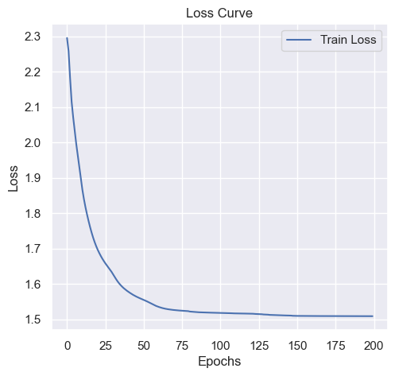

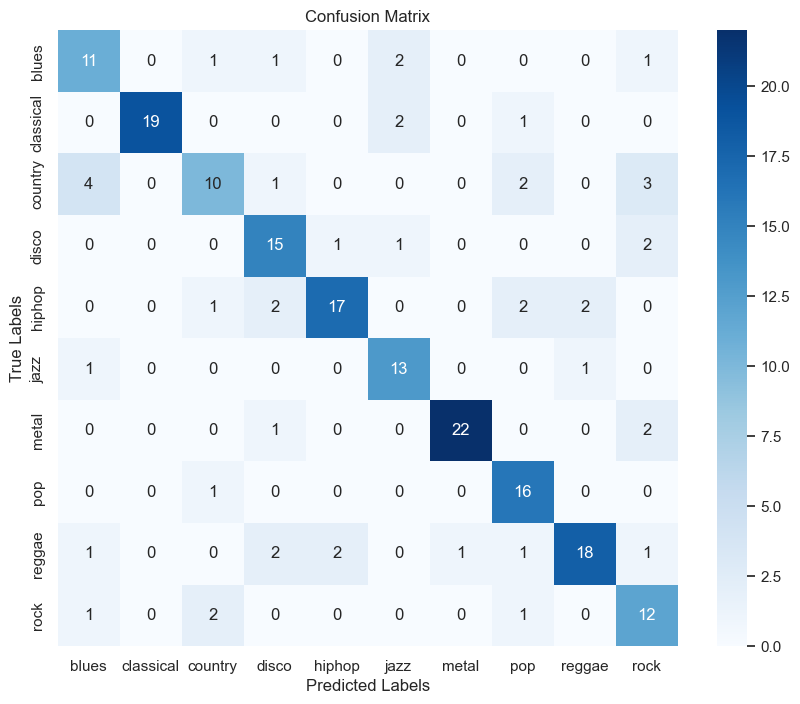